# Practical Machine Learning Course Project

by Bhanu Bhakta Sigdel

## Introduction

Using devices such as Jawbone Up, Nike FuelBand, and Fitbit it is now possible to collect a large amount of data about personal activity relatively inexpensively. These type of devices are part of the quantified self movement ??? a group of enthusiasts who take measurements about themselves regularly to improve their health, to find patterns in their behavior, or because they are tech geeks. One thing that people regularly do is quantify how much of a particular activity they do, but they rarely quantify how well they do it.

In this project, we will use data from accelerometers on the belt, forearm, arm, and dumbell of 6 participants to predict the manner in which they did the exercise.

## Load required libraries

```r
library(caret)
```

```r
library(rpart)
library(rpart.plot)
library(randomForest)
library(e1071)
```

## Collect the required data

```r
# The training and test data url.
trainingDataUrl <- "https://d396qusza40orc.cloudfront.net/predmachlearn/pml-training.csv"
testDataUrl <- "https://d396qusza40orc.cloudfront.net/predmachlearn/pml-testing.csv"

# Create input_data folder.
if(!file.exists("./input_data")) {
  dir.create("./input_data")
}

# Downloading and storing data locally.
trainingDataFile <- "./input_data/training_data.csv"
testDataFile <- "./input_data/test_data.csv"

if(!file.exists(trainingDataFile)) {
  download.file(trainingDataUrl, destfile = trainingDataFile, method = "curl")
}

if(!file.exists(testDataFile)) {
  download.file(testDataUrl, destfile = testDataFile, method = "curl")
}

# Read the data.

trainingDataRaw <- read.csv(trainingDataFile)
testDataRaw <- read.csv(testDataFile)

trainingDataRawDim <- dim(trainingDataRaw)
testDataRawDim <- dim(testDataRaw)

print(paste("Training Data Dimensions: ", trainingDataRawDim[1], "*", trainingDataRawDim[2]))
```

```
## [1] "Training Data Dimensions:  19622 * 160"
```

```r
print(paste("Test Data Dimensions: ", testDataRawDim[1], "*", testDataRawDim[2]))
```

```
## [1] "Test Data Dimensions:  20 * 160"
```

The classe is the outcome variable we are going to predict.

## Cleaning the data.

```r
sum(complete.cases(trainingDataRaw))
```

```
## [1] 406
```

Since, we have missing values, lets start cleaning data by removing columns with missing(N/A) values.

# Removing the columns containing the missing values.

```r
trainingDataRaw <- trainingDataRaw[ ,colSums(is.na(trainingDataRaw)) == 0]
testDataRaw <- testDataRaw[ ,colSums(is.na(testDataRaw)) == 0]
colnames(trainingDataRaw)
```

```
##  [1] "X"                       "user_name"
##  [3] "raw_timestamp_part_1"    "raw_timestamp_part_2"
##  [5] "cvtd_timestamp"          "new_window"
##  [7] "num_window"              "roll_belt"
##  [9] "pitch_belt"              "yaw_belt"
## [11] "total_accel_belt"        "kurtosis_roll_belt"
## [13] "kurtosis_picth_belt"     "kurtosis_yaw_belt"
## [15] "skewness_roll_belt"      "skewness_roll_belt.1"
## [17] "skewness_yaw_belt"       "max_yaw_belt"
## [19] "min_yaw_belt"            "amplitude_yaw_belt"
## [21] "gyros_belt_x"            "gyros_belt_y"
## [23] "gyros_belt_z"            "accel_belt_x"
## [25] "accel_belt_y"            "accel_belt_z"
## [27] "magnet_belt_x"           "magnet_belt_y"
## [29] "magnet_belt_z"           "roll_arm"
```

[output cut: 32 more lines]

Since we are interested with the data from accelerometers on the belt, forearm, arm, and dumbell, user_name, window and timestamp variables won’t contribute for the outcome. Lets get rid of these columns.

```r
trainingToRemove <- grepl("^X|timestamp|window|user_name", names(trainingDataRaw))
testToRemove <- grepl("^X|timestamp|window|user_name", names(testDataRaw))

trainingDataRaw <- trainingDataRaw[ , !trainingToRemove]
testDataRaw <- testDataRaw[ , !testToRemove]
```

Get rid of the data that are not numeric too.

```r
classe <- trainingDataRaw$classe
trainingDataCleaned <- trainingDataRaw[, sapply(trainingDataRaw, is.numeric)]
trainingDataCleaned$classe <- classe

testDataCleaned <- testDataRaw[, sapply(testDataRaw, is.numeric)]
```

## Partation the training data into pure training and validation set.

We split the cleaned training set into a pure training data set (75%) and a validation data set (25%). We will use the validation data set to conduct cross validation in future steps.

```r
set.seed(113456)

inTrain <- createDataPartition(trainingDataCleaned$classe, p=0.75, list=F)
trainingData <- trainingDataCleaned[inTrain, ]
validationData <- trainingDataCleaned[-inTrain, ]
```

## Using algorithm for prediction.

I prefer using Random Forest algorithm to fit a predictive model for activity recognition as Random Forests are often the winner for lots of problems in classification. Also Random Forests automatically selects important variables and is robust to correlated covariates & outliers in general. We will use 5-fold cross validation when applying the algorithm.

```r
controlRandomForest <- trainControl(method="cv", 5)
modelRandomForest <- train(classe ~ ., data=trainingData, method="rf", trControl=controlRandomForest, ntree=200)
modelRandomForest
```

```
## Random Forest
##
## 14718 samples
##    52 predictor
##     5 classes: 'A', 'B', 'C', 'D', 'E'
##
## No pre-processing
## Resampling: Cross-Validated (5 fold)
##
## Summary of sample sizes: 11776, 11773, 11774, 11774, 11775
##
## Resampling results across tuning parameters:
##
##   mtry  Accuracy   Kappa      Accuracy SD   Kappa SD
##    2    0.9907596  0.9883104  0.0013881235  0.001756459
##   27    0.9911675  0.9888267  0.0008635035  0.001092206
##   52    0.9866157  0.9830673  0.0025326874  0.003205150
##
## Accuracy was used to select the optimal model using  the largest value.
## The final value used for the model was mtry = 27.
```

## Estimating the performance of the model in the validation sets.

```r
predictRandomForest <- predict(modelRandomForest, validationData)
confusionMatrix(validationData$classe, predictRandomForest)
```

```
## Confusion Matrix and Statistics
##
##           Reference
## Prediction    A    B    C    D    E
##          A 1394    1    0    0    0
##          B    7  940    2    0    0
##          C    0    5  849    1    0
##          D    0    0    4  800    0
##          E    0    0    2    2  897
##
## Overall Statistics
##
##                Accuracy : 0.9951
##                  95% CI : (0.9927, 0.9969)
##     No Information Rate : 0.2857
##     P-Value [Acc > NIR] : < 2.2e-16
##
##                   Kappa : 0.9938
##  Mcnemar's Test P-Value : NA
##
## Statistics by Class:
##
##                      Class: A Class: B Class: C Class: D Class: E
## Sensitivity            0.9950   0.9937   0.9907   0.9963   1.0000
## Specificity            0.9997   0.9977   0.9985   0.9990   0.9990
## Pos Pred Value         0.9993   0.9905   0.9930   0.9950   0.9956
## Neg Pred Value         0.9980   0.9985   0.9980   0.9993   1.0000
## Prevalence             0.2857   0.1929   0.1748   0.1637   0.1829
## Detection Rate         0.2843   0.1917   0.1731   0.1631   0.1829
## Detection Prevalence   0.2845   0.1935   0.1743   0.1639   0.1837
## Balanced Accuracy      0.9974   0.9957   0.9946   0.9976   0.9995
```

```r
accuracy <- postResample(predictRandomForest, validationData$classe)
out_of_sample_error <-  1 - as.numeric(confusionMatrix(validationData$classe, predictRandomForest)$overall[1])
out_of_sample_error
```

```
## [1] 0.004893964
```

```r
accuracy
```

```
##  Accuracy     Kappa
## 0.9951060 0.9938089
```

Hence the estimated accuracy of the model is 99.51% and the estimated out of sample error is 0.48%

## Predicting for Test Data Set

Applying the model to predict for the testing data set we had download previously from the provided source.Since, there is problem_id in the data, lets remove that.

```r
result <- predict(modelRandomForest, testDataCleaned[, -ncol(testDataCleaned)])
result
```

```
##  [1] B A B A A E D B A A B C B A E E A B B B
## Levels: A B C D E
```

## Decision tree visualization

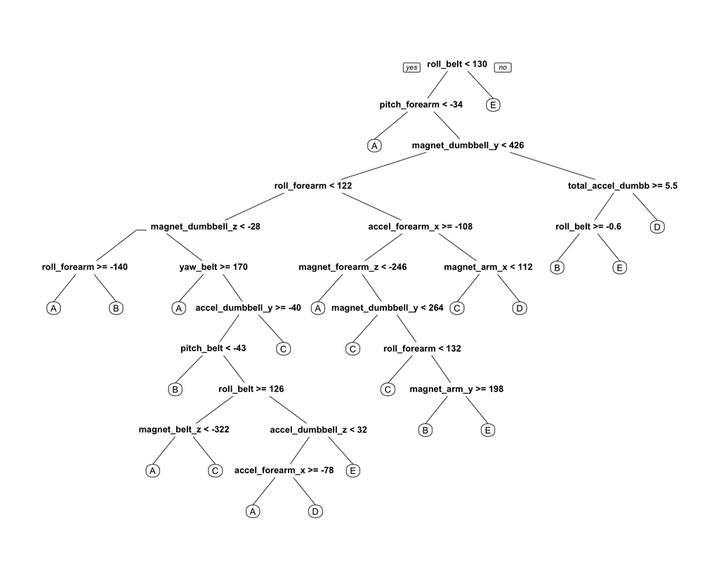

```r
treeModel <- rpart(classe ~ ., data=trainingData, method="class")
prp(treeModel)
```

[figure not shown]